# COM 6042: Project.

# Machine Learning Project on Online Shopper's Purchase Intention

## Importing Essential Libraries

```python
import pandas as pd
import numpy as np
import matplotlib.pyplot as plt
%matplotlib inline
import seaborn as sns
from sklearn.preprocessing import LabelEncoder, OneHotEncoder
from sklearn.preprocessing import MinMaxScaler
from sklearn.model_selection import train_test_split
from imblearn.over_sampling import RandomOverSampler
import xgboost as xgb
from sklearn.ensemble import RandomForestClassifier
from sklearn.neighbors import KNeighborsClassifier
from sklearn.metrics import accuracy_score
from sklearn.metrics import classification_report
from sklearn.metrics import confusion_matrix
from sklearn.metrics import roc_curve, roc_auc_score
```

The necessary libraries have been imported in this portion, including Pandas, Numpy, Matplotlib, Seaborn, Scikit-learn's LabelEncoder, OneHotEncoder, MinMaxScaler, train_test_split, RandomOverSampler, XGBoost, RandomForestClassifier, KNeighborsClassifier, and various metrics such as accuracy score, classification report, confusion matrix, ROC curve, and ROC AUC score.

## Loading The Dataset

```python
df = pd.read_csv("online_shoppers_intention.csv")
```

In this section of the project, the dataset has been loaded by executing the following code: df = pd.read csv("online shoppers intention.csv").

```python
df.head()
```

|  | Administrative | Administrative_Duration | Informational | Informational_Duration | ProductRelated | ProductRelated_Duration | BounceRates | ExitRates | PageValues | SpecialDay | Month | OperatingSystems | Browser | Region | TrafficType | VisitorType | Weekend | Revenue |
| --- | --- | --- | --- | --- | --- | --- | --- | --- | --- | --- | --- | --- | --- | --- | --- | --- | --- | --- |
| 0 | 0 | 0.0 | 0 | 0.0 | 1 | 0.000000 | 0.20 | 0.20 | 0.0 | 0.0 | Feb | 1 | 1 | 1 | 1 | Returning_Visitor | False | False |
| 1 | 0 | 0.0 | 0 | 0.0 | 2 | 64.000000 | 0.00 | 0.10 | 0.0 | 0.0 | Feb | 2 | 2 | 1 | 2 | Returning_Visitor | False | False |
| 2 | 0 | 0.0 | 0 | 0.0 | 1 | 0.000000 | 0.20 | 0.20 | 0.0 | 0.0 | Feb | 4 | 1 | 9 | 3 | Returning_Visitor | False | False |
| 3 | 0 | 0.0 | 0 | 0.0 | 2 | 2.666667 | 0.05 | 0.14 | 0.0 | 0.0 | Feb | 3 | 2 | 2 | 4 | Returning_Visitor | False | False |
| 4 | 0 | 0.0 | 0 | 0.0 | 10 | 627.500000 | 0.02 | 0.05 | 0.0 | 0.0 | Feb | 3 | 3 | 1 | 4 | Returning_Visitor | True | False |

```python
df.tail()
```

|  | Administrative | Administrative_Duration | Informational | Informational_Duration | ProductRelated | ProductRelated_Duration | BounceRates | ExitRates | PageValues | SpecialDay | Month | OperatingSystems | Browser | Region | TrafficType | VisitorType | Weekend | Revenue |
| --- | --- | --- | --- | --- | --- | --- | --- | --- | --- | --- | --- | --- | --- | --- | --- | --- | --- | --- |
| 12325 | 3 | 145.0 | 0 | 0.0 | 53 | 1783.791667 | 0.007143 | 0.029031 | 12.241717 | 0.0 | Dec | 4 | 6 | 1 | 1 | Returning_Visitor | True | False |
| 12326 | 0 | 0.0 | 0 | 0.0 | 5 | 465.750000 | 0.000000 | 0.021333 | 0.000000 | 0.0 | Nov | 3 | 2 | 1 | 8 | Returning_Visitor | True | False |
| 12327 | 0 | 0.0 | 0 | 0.0 | 6 | 184.250000 | 0.083333 | 0.086667 | 0.000000 | 0.0 | Nov | 3 | 2 | 1 | 13 | Returning_Visitor | True | False |
| 12328 | 4 | 75.0 | 0 | 0.0 | 15 | 346.000000 | 0.000000 | 0.021053 | 0.000000 | 0.0 | Nov | 2 | 2 | 3 | 11 | Returning_Visitor | False | False |
| 12329 | 0 | 0.0 | 0 | 0.0 | 3 | 21.250000 | 0.000000 | 0.066667 | 0.000000 | 0.0 | Nov | 3 | 2 | 1 | 2 | New_Visitor | True | False |

## Dataset's Features Explanation

- Administrative: Number of pages visited by the visitor about the website's administration.
- Administrative_Duration: Total time spent by the visitor on the administrative pages.
- Informational: Number of pages visited by the visitor that provide information about the website.
- Informational_Duration: Total time spent by the visitor on the informational pages.
- ProductRelated: Number of pages visited by the visitor that relate to products or services.
- ProductRelated_Duration: Total time spent by the visitor on the product-related pages.
- BounceRates: The percentage of visitors who leave the website after visiting only one page.
- ExitRates: The percentage of visitors who leave the website after visiting one or more pages.
- PageValues: Average value of the pages visited by the visitor.
- SpecialDay: The closeness of the website visiting time to a special day (e.g. Mother's Day, Valentine's Day).
- Month: Month of the year in which the website was visited.
- OperatingSystems: The operating system of the visitor's computer.
- Browser: The browser used by the visitor to access the website.
- Region: The geographic region from which the visitor accesses the website.
- TrafficType: Traffic source of the visitor.
- VisitorType: Type of visitor to the website (e.g. returning or new).
- Weekend: A binary indicator whether the visitor accessed the website during a weekend.
- Revenue: A binary indicator of whether the visitor made a purchase on the website.

The dataset has been obtained from the UCI Machine Learning Repository, you can find the link here: https://archive.ics.uci.edu/ml/datasets/Online+Shoppers+Purchasing+Intention+Dataset

## Understanding the Data

```python
df.info()
```

```
<class 'pandas.core.frame.DataFrame'>
RangeIndex: 12330 entries, 0 to 12329
Data columns (total 18 columns):
 #   Column                   Non-Null Count  Dtype
---  ------                   --------------  -----
 0   Administrative           12330 non-null  int64
 1   Administrative_Duration  12330 non-null  float64
 2   Informational            12330 non-null  int64
 3   Informational_Duration   12330 non-null  float64
 4   ProductRelated           12330 non-null  int64
 5   ProductRelated_Duration  12330 non-null  float64
 6   BounceRates              12330 non-null  float64
 7   ExitRates                12330 non-null  float64
 8   PageValues               12330 non-null  float64
 9   SpecialDay               12330 non-null  float64
 10  Month                    12330 non-null  object
 11  OperatingSystems         12330 non-null  int64
 12  Browser                  12330 non-null  int64
 13  Region                   12330 non-null  int64
 14  TrafficType              12330 non-null  int64
 15  VisitorType              12330 non-null  object
 16  Weekend                  12330 non-null  bool
 17  Revenue                  12330 non-null  bool
dtypes: bool(2), float64(7), int64(7), object(2)
memory usage: 1.5+ MB
```

The df.info() function displays details about the dataframe, such as the number of rows and columns, data types, non-null values, and memory utilisation.

```python
df.shape
```

```
(12330, 18)
```

The dataframe has 12330 rows and 18 columns.

```python
df.columns
```

```
Index(['Administrative', 'Administrative_Duration', 'Informational',
       'Informational_Duration', 'ProductRelated', 'ProductRelated_Duration',
       'BounceRates', 'ExitRates', 'PageValues', 'SpecialDay', 'Month',
       'OperatingSystems', 'Browser', 'Region', 'TrafficType', 'VisitorType',
       'Weekend', 'Revenue'],
      dtype='object')
```

The df.columns has been used to display the names of the columns in the dataframe df.

```python
df.nunique()
```

```
Administrative               27
Administrative_Duration    3335
Informational                17
Informational_Duration     1258
ProductRelated              311
ProductRelated_Duration    9551
BounceRates                1872
ExitRates                  4777
PageValues                 2704
SpecialDay                    6
Month                        10
OperatingSystems              8
Browser                      13
Region                        9
TrafficType                  20
VisitorType                   3
Weekend                       2
Revenue                       2
dtype: int64
```

The number of unique values in each column is returned by the pandas dataframe's df.nunique() method. We can see from this dataframe that ProductRelated Duration has the most unique entries overall, while Weekend and Revenue have the fewest. where the corresponding entries for the categorical attributes Month, VisitorType, Weekend, and Revenue are 10, 3, 2, and 2, respectively.

```python
df.isnull().sum()
```

```
Administrative             0
Administrative_Duration    0
Informational              0
Informational_Duration     0
ProductRelated             0
ProductRelated_Duration    0
BounceRates                0
ExitRates                  0
PageValues                 0
SpecialDay                 0
Month                      0
OperatingSystems           0
Browser                    0
Region                     0
TrafficType                0
VisitorType                0
Weekend                    0
Revenue                    0
dtype: int64
```

This code returns the count of missing or null values in each column of the dataframe 'df'. As an outcome, it is evident that no null value exists.

```python
df.describe()
```

|  | Administrative | Administrative_Duration | Informational | Informational_Duration | ProductRelated | ProductRelated_Duration | BounceRates | ExitRates | PageValues | SpecialDay | OperatingSystems | Browser | Region | TrafficType |
| --- | --- | --- | --- | --- | --- | --- | --- | --- | --- | --- | --- | --- | --- | --- |
| count | 12330.000000 | 12330.000000 | 12330.000000 | 12330.000000 | 12330.000000 | 12330.000000 | 12330.000000 | 12330.000000 | 12330.000000 | 12330.000000 | 12330.000000 | 12330.000000 | 12330.000000 | 12330.000000 |
| mean | 2.315166 | 80.818611 | 0.503569 | 34.472398 | 31.731468 | 1194.746220 | 0.022191 | 0.043073 | 5.889258 | 0.061427 | 2.124006 | 2.357097 | 3.147364 | 4.069586 |
| std | 3.321784 | 176.779107 | 1.270156 | 140.749294 | 44.475503 | 1913.669288 | 0.048488 | 0.048597 | 18.568437 | 0.198917 | 0.911325 | 1.717277 | 2.401591 | 4.025169 |
| min | 0.000000 | 0.000000 | 0.000000 | 0.000000 | 0.000000 | 0.000000 | 0.000000 | 0.000000 | 0.000000 | 0.000000 | 1.000000 | 1.000000 | 1.000000 | 1.000000 |
| 25% | 0.000000 | 0.000000 | 0.000000 | 0.000000 | 7.000000 | 184.137500 | 0.000000 | 0.014286 | 0.000000 | 0.000000 | 2.000000 | 2.000000 | 1.000000 | 2.000000 |
| 50% | 1.000000 | 7.500000 | 0.000000 | 0.000000 | 18.000000 | 598.936905 | 0.003112 | 0.025156 | 0.000000 | 0.000000 | 2.000000 | 2.000000 | 3.000000 | 2.000000 |
| 75% | 4.000000 | 93.256250 | 0.000000 | 0.000000 | 38.000000 | 1464.157214 | 0.016813 | 0.050000 | 0.000000 | 0.000000 | 3.000000 | 2.000000 | 4.000000 | 4.000000 |
| max | 27.000000 | 3398.750000 | 24.000000 | 2549.375000 | 705.000000 | 63973.522230 | 0.200000 | 0.200000 | 361.763742 | 1.000000 | 8.000000 | 13.000000 | 9.000000 | 20.000000 |

For the dataframe "df," this code creates descriptive statistics. The key characteristics of a dataset are condensed in descriptive statistics. It gives statistics for each column in the dataframe, such as count, mean, standard deviation, minimum, 25th, 50th (median), 75th, and maximum values. It is beneficial to comprehend the data's distribution and spot any outliers or extreme numbers.

## Exploratory Data Analysis (EDA)

```python
df.head(2)
```

|  | Administrative | Administrative_Duration | Informational | Informational_Duration | ProductRelated | ProductRelated_Duration | BounceRates | ExitRates | PageValues | SpecialDay | Month | OperatingSystems | Browser | Region | TrafficType | VisitorType | Weekend | Revenue |
| --- | --- | --- | --- | --- | --- | --- | --- | --- | --- | --- | --- | --- | --- | --- | --- | --- | --- | --- |
| 0 | 0 | 0.0 | 0 | 0.0 | 1 | 0.0 | 0.2 | 0.2 | 0.0 | 0.0 | Feb | 1 | 1 | 1 | 1 | Returning_Visitor | False | False |
| 1 | 0 | 0.0 | 0 | 0.0 | 2 | 64.0 | 0.0 | 0.1 | 0.0 | 0.0 | Feb | 2 | 2 | 1 | 2 | Returning_Visitor | False | False |

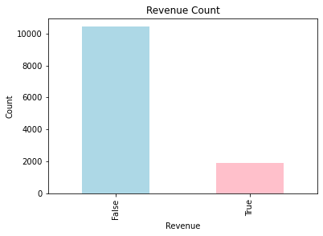

```python
df.Revenue.value_counts().plot(kind='bar', color=['lightblue', 'pink'])
plt.xlabel('Revenue')
plt.ylabel('Count')
plt.title('Revenue Count')
```

In the dataframe 'df"s 'Revenue' column, this code creates a bar plot that displays the count of two values (False and True). The "True" value has a count of 2,000, whereas the "False" value has a count of over 10,000.

```python
admin_counts = df['Administrative'].groupby(df['Revenue']).count()
non_zero_values = admin_counts[1] / admin_counts.sum() * 100
non_zero_values
```

```
15.474452554744525
```

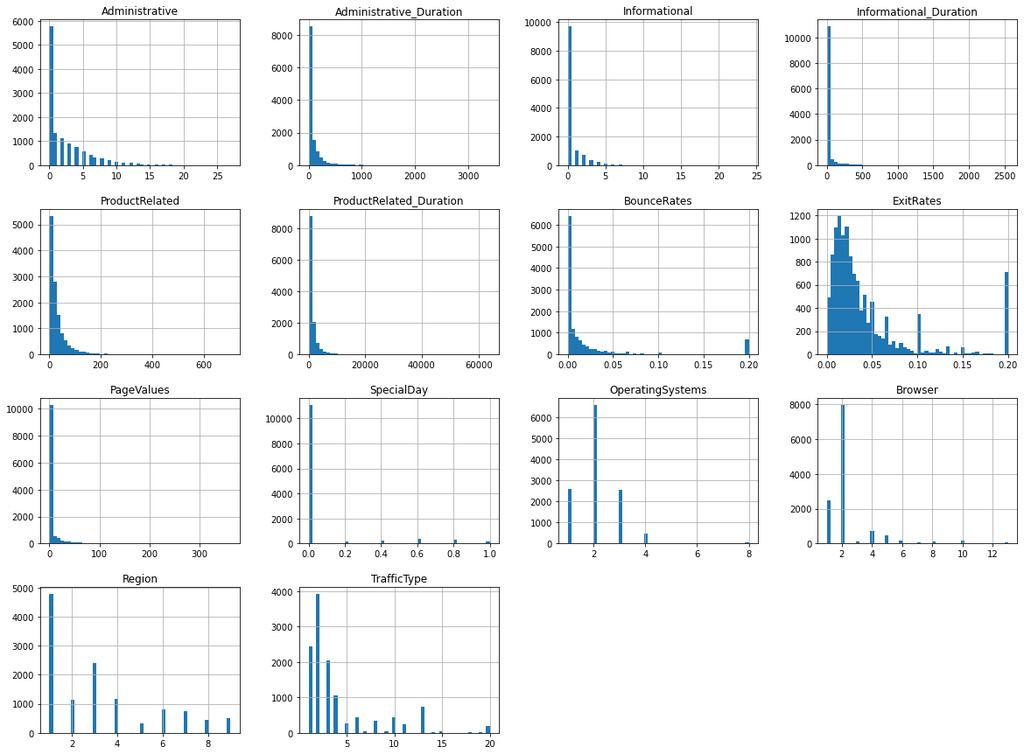

```python
df.hist(bins=50, figsize=(20,15))
plt.show()
```

By producing histograms for each column with 50 bins, this code illustrates the distribution of each column in the dataframe "df." Furthermore, these histograms display the frequency information for the range.

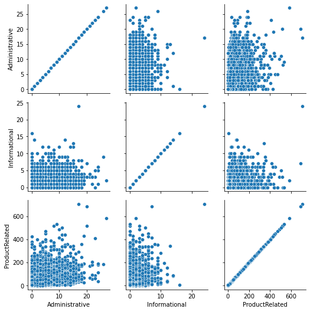

```python
g = sns.PairGrid(data=df, vars=['Administrative','Informational','ProductRelated'])
g.map(sns.scatterplot)
plt.show()
```

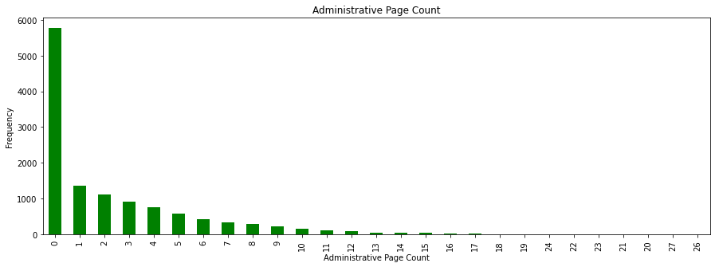

```python
plt.figure(figsize=(15,5))
df['Administrative'].value_counts().plot(kind='bar',color='green')
plt.xlabel('Administrative Page Count')
plt.ylabel('Frequency')
plt.title('Administrative Page Count')
plt.show()
```

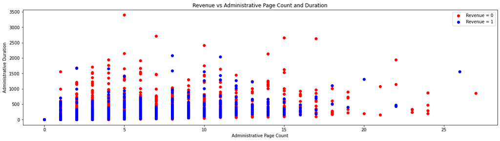

```python
plt.figure(figsize=(20,5))
plt.scatter(df.loc[df['Revenue'] == 0, 'Administrative'], df.loc[df['Revenue'] == 0, 'Administrative_Duration'], color='red',label='Revenue = 0')
plt.scatter(df.loc[df['Revenue'] == 1, 'Administrative'], df.loc[df['Revenue'] == 1, 'Administrative_Duration'], color='blue',label='Revenue = 1')
plt.xlabel('Administrative Page Count')
plt.ylabel('Administrative Duration')
plt.title('Revenue vs Administrative Page Count and Duration')
plt.legend()
plt.show()
```

The association between two features in the dataframe 'df': "Administrative Page Count" and "Administrative Duration" is visualised using a scatter plot using this code. Using "Revenue" as the objective feature, the scatter plot divides the data points into two classes. Points marked "Revenue = 0" and "Revenue = 1" are displayed in red and blue, respectively.

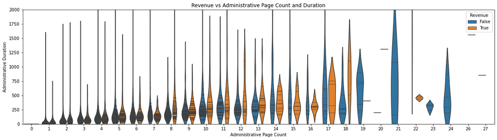

```python
plt.figure(figsize=(20,5))
sns.violinplot(x='Administrative', y='Administrative_Duration', hue='Revenue', data=df, inner='stick')
plt.ylim(0,2000)
plt.xlabel('Administrative Page Count')
plt.ylabel('Administrative Duration')
plt.title('Revenue vs Administrative Page Count and Duration')
plt.show()
```

When the number of visits to Administrative pages is high, typically over 19, there is a low likelihood of generating revenue. On the other hand, when the number of visits is low, less than 7, individuals tend to spend less time on these pages, which also decreases the chances of making a deal. However, when the number of visits falls between 8 and 18, individuals tend to spend more time reading about the Administrative pages, which increases the chances of making a purchase.

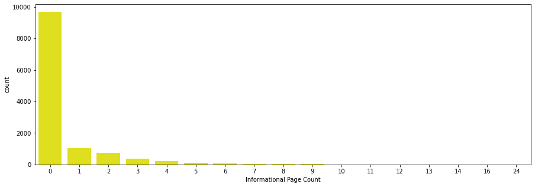

```python
plt.figure(figsize=(15,5))
sns.countplot(x='Informational',data=df, color='Yellow')
plt.xlabel('Informational Page Count')
```

The data shows that people tend not to frequently visit pages related to informational content, meaning they do not visit these types of pages frequently.

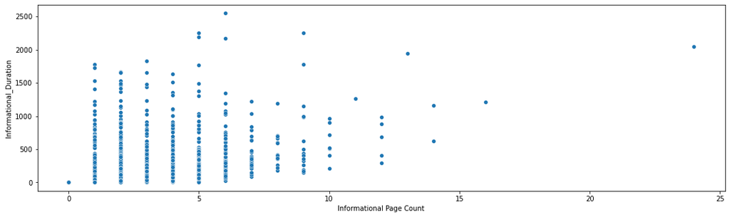

```python
plt.figure(figsize=(18,5))
sns.scatterplot(x='Informational',y='Informational_Duration',data=df)
plt.xlabel('Informational Page Count')
```

Using the Seaborn library, this code generates a scatter plot to display the correlation between the Informational page count and the Informational duration in the 'df' dataframe. The scatter plot enables us to see the relationship between the frequency of visits to informational pages and the time spent on those pages. Users spend more time on the fifth, sixth, and ninth pages than on the others, as can be observed.

```
(0.0, 2000.0)
```

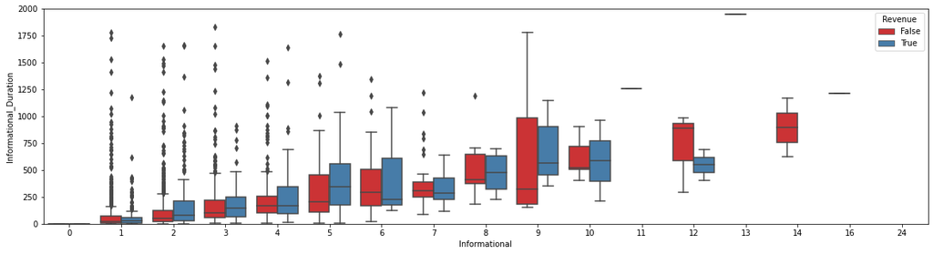

```python
plt.figure(figsize=(20,5))
sns.boxplot(x='Informational',y='Informational_Duration',hue='Revenue',data=df,palette='Set1')
plt.ylim(0,2000)
```

There is an indication that individuals tend to spend a significant amount of time on Information-related pages when making a purchase.

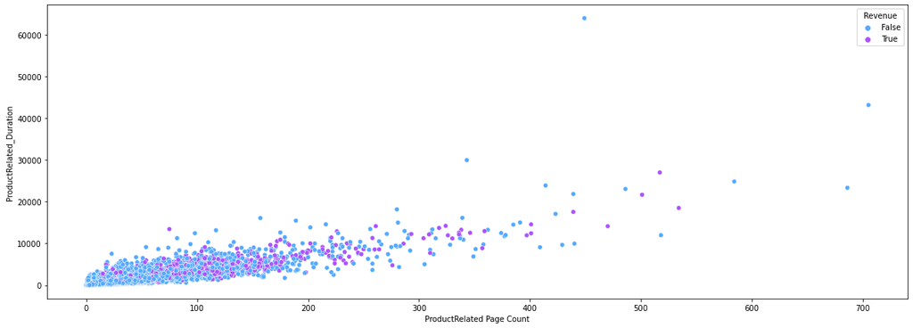

```python
plt.figure(figsize=(20,7))
sns.scatterplot(x='ProductRelated',y='ProductRelated_Duration',hue='Revenue',data=df,palette='cool')
plt.xlabel('ProductRelated Page Count')
```

There is a higher frequency of visits to Product-related pages as compared to Administrative or Information-related pages.

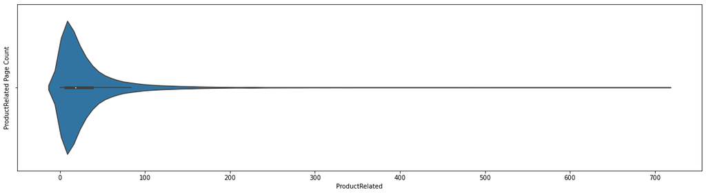

```python
plt.figure(figsize=(20,5))
sns.violinplot(x='ProductRelated', data=df, orient='v')
plt.ylabel('ProductRelated Page Count')
```

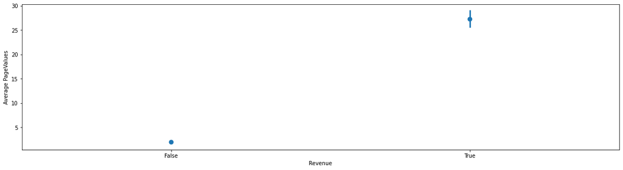

```python
plt.figure(figsize=(20,5))
sns.pointplot(x='Revenue', y='PageValues', data=df, join=False)
plt.ylabel('Average PageValues')
```

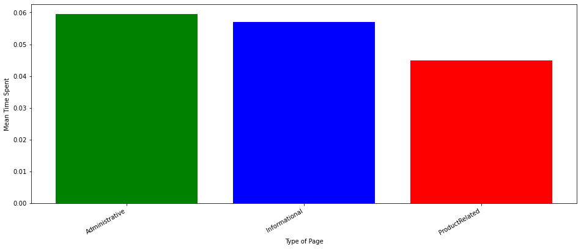

```python
fig, ax = plt.subplots(figsize=(16,6))
page_types = ['Administrative','Informational','ProductRelated']
page_means = [np.mean((df[page]/df[page + '_Duration']).replace(np.inf,np.nan).dropna()) for page in page_types]
ax.bar(page_types, page_means, color=['green','blue','red'])
ax.set_xlabel('Type of Page')
ax.set_ylabel('Mean Time Spent')
ax.set_xticklabels(page_types, rotation=30, ha='right', fontsize=10)
plt.show()
```

```python
counts = df.groupby(['Revenue', 'OperatingSystems']).size().reset_index(name='counts')
counts
```

|  | Revenue | OperatingSystems | counts |
| --- | --- | --- | --- |
| 0 | False | 1 | 2206 |
| 1 | False | 2 | 5446 |
| 2 | False | 3 | 2287 |
| 3 | False | 4 | 393 |
| 4 | False | 5 | 5 |
| 5 | False | 6 | 17 |
| 6 | False | 7 | 6 |
| 7 | False | 8 | 62 |
| 8 | True | 1 | 379 |
| 9 | True | 2 | 1155 |
| 10 | True | 3 | 268 |
| 11 | True | 4 | 85 |
| 12 | True | 5 | 1 |
| 13 | True | 6 | 2 |
| 14 | True | 7 | 1 |
| 15 | True | 8 | 17 |

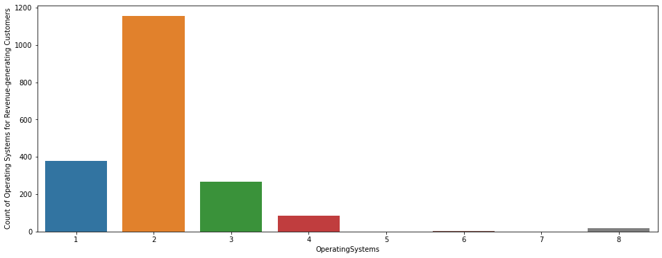

```python
plt.figure(figsize=(16,6))
df_revenue = df[df['Revenue'] == True]
sns.countplot(x='OperatingSystems', data=df_revenue)
plt.ylabel('Count of Operating Systems for Revenue-generating Customers')
```

```python
br_counts = df.groupby(['Revenue','Browser']).size().reset_index(name='counts')
br_counts
```

|  | Revenue | Browser | counts |
| --- | --- | --- | --- |
| 0 | False | 1 | 2097 |
| 1 | False | 2 | 6738 |
| 2 | False | 3 | 100 |
| 3 | False | 4 | 606 |
| 4 | False | 5 | 381 |
| 5 | False | 6 | 154 |
| 6 | False | 7 | 43 |
| 7 | False | 8 | 114 |
| 8 | False | 9 | 1 |
| 9 | False | 10 | 131 |
| 10 | False | 11 | 5 |
| 11 | False | 12 | 7 |
| 12 | False | 13 | 45 |
| 13 | True | 1 | 365 |
| 14 | True | 2 | 1223 |
| 15 | True | 3 | 5 |
| 16 | True | 4 | 130 |
| 17 | True | 5 | 86 |
| 18 | True | 6 | 20 |
| 19 | True | 7 | 6 |
| 20 | True | 8 | 21 |
| 21 | True | 10 | 32 |
| 22 | True | 11 | 1 |
| 23 | True | 12 | 3 |
| 24 | True | 13 | 16 |

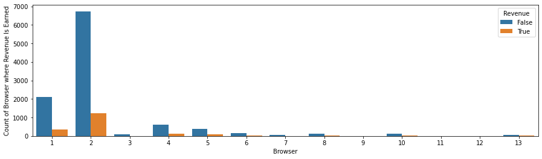

```python
df_browser = df.groupby(['Revenue', 'Browser']).size().reset_index(name='counts')
plt.figure(figsize=(15,4))
sns.barplot(x='Browser',y='counts',hue='Revenue',data=df_browser)
plt.ylabel('Count of Browser where Revenue Is Earned')
plt.show()
```

It appears that a significant number of users who generate revenue tend to use Browser '2'. To reach a wider audience, it may be beneficial to focus advertising efforts on that particular browser.

```python
reg_counts = df.groupby(['Revenue', 'Region']).size().reset_index(name='Counts')
reg_counts
```

|  | Revenue | Region | Counts |
| --- | --- | --- | --- |
| 0 | False | 1 | 4009 |
| 1 | False | 2 | 948 |
| 2 | False | 3 | 2054 |
| 3 | False | 4 | 1007 |
| 4 | False | 5 | 266 |
| 5 | False | 6 | 693 |
| 6 | False | 7 | 642 |
| 7 | False | 8 | 378 |
| 8 | False | 9 | 425 |
| 9 | True | 1 | 771 |
| 10 | True | 2 | 188 |
| 11 | True | 3 | 349 |
| 12 | True | 4 | 175 |
| 13 | True | 5 | 52 |
| 14 | True | 6 | 112 |
| 15 | True | 7 | 119 |
| 16 | True | 8 | 56 |
| 17 | True | 9 | 86 |

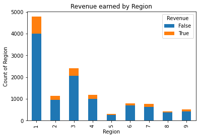

```python
plt.figure(figsize=(15,4))
df.groupby(['Region','Revenue']).size().unstack().plot(kind='bar', stacked=True)
plt.ylabel('Count of Region')
plt.xlabel('Region')
plt.title('Revenue earned by Region')
```

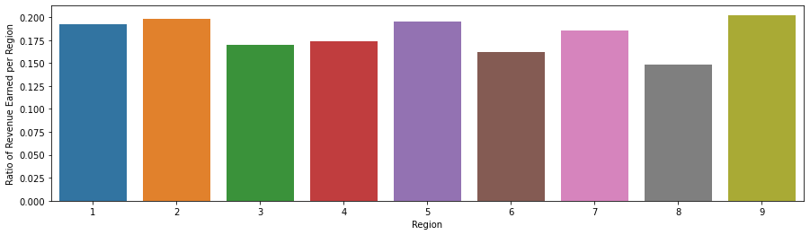

```python
sr=df.groupby('Revenue')['Region'].value_counts()
srf=pd.DataFrame(sr[False])
srt=pd.DataFrame(sr[True])
srp=srt/srf
plt.figure(figsize=(15,4))
sns.barplot(x=srp.index, y=srp['Region'])
plt.ylabel('Ratio of Revenue Earned per Region')
```

In Region '9', though the number of visitors is lower compared to other regions, the likelihood of making a purchase is the highest. On the other hand, Region '8' is not a favorable location for this business as the conversion rate is low, even with fewer visitors.

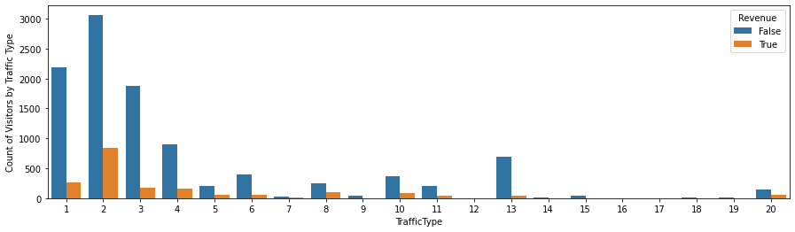

```python
tf_df = df.groupby(['TrafficType', 'Revenue']).size().reset_index(name='counts')
plt.figure(figsize=(15,4))
sns.barplot(x='TrafficType', y='counts', hue='Revenue', data=tf_df)
plt.ylabel('Count of Visitors by Traffic Type')
```

Advertising through Traffic Type '2' is the most effective method as it brings in the most number of customers to the website.

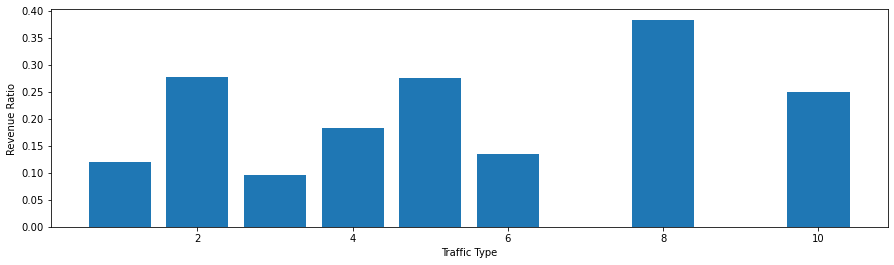

```python
plt.figure(figsize=(15,4))
tf_false = df[df['Revenue'] == False].groupby('TrafficType').size().reset_index(name='counts')
tf_true = df[df['Revenue'] == True].groupby('TrafficType').size().reset_index(name='counts')
tf_ratio = tf_true.merge(tf_false, on='TrafficType', suffixes=('_true', '_false'))
tf_ratio['ratio'] = tf_ratio['counts_true'] / tf_ratio['counts_false']
tf_ratio = tf_ratio[tf_ratio['counts_true'] > 50]
tf_ratio = tf_ratio[tf_ratio['counts_false'] > 50]
tf_ratio = tf_ratio.sort_values(by='ratio', ascending=False)
plt.bar(tf_ratio['TrafficType'], tf_ratio['ratio'])
plt.xlabel('Traffic Type')
plt.ylabel('Revenue Ratio')
plt.show()
```

People who are directed to the website through Traffic Type '8' tend to make the most purchases. This suggests that advertising through this medium may be more effective.

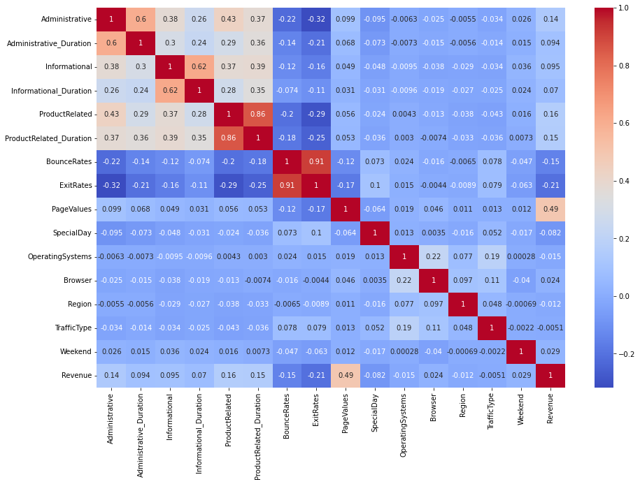

```python
plt.figure(figsize=(15,10))
sns.heatmap(df.corr(), annot=True, cmap='coolwarm')
plt.show()
```

We can observe from the heatmap that the features "Administrative Duration," "Informational Duration," "ProductRelated Duration," "BounceRates," "ExitRates," "PageValues," and "Revenue" have the ideal positive and negative association. This statistical measure of correlation must therefore be taken into account for feature engineering.

## Data Preprocessing

```python
df.isnull().sum()
```

```
Administrative             0
Administrative_Duration    0
Informational              0
Informational_Duration     0
ProductRelated             0
ProductRelated_Duration    0
BounceRates                0
ExitRates                  0
PageValues                 0
SpecialDay                 0
Month                      0
OperatingSystems           0
Browser                    0
Region                     0
TrafficType                0
VisitorType                0
Weekend                    0
Revenue                    0
dtype: int64
```

There are no null values in the dataset.

```python
df.info()
```

```
<class 'pandas.core.frame.DataFrame'>
RangeIndex: 12330 entries, 0 to 12329
Data columns (total 18 columns):
 #   Column                   Non-Null Count  Dtype
---  ------                   --------------  -----
 0   Administrative           12330 non-null  int64
 1   Administrative_Duration  12330 non-null  float64
 2   Informational            12330 non-null  int64
 3   Informational_Duration   12330 non-null  float64
 4   ProductRelated           12330 non-null  int64
 5   ProductRelated_Duration  12330 non-null  float64
 6   BounceRates              12330 non-null  float64
 7   ExitRates                12330 non-null  float64
 8   PageValues               12330 non-null  float64
 9   SpecialDay               12330 non-null  float64
 10  Month                    12330 non-null  object
 11  OperatingSystems         12330 non-null  int64
 12  Browser                  12330 non-null  int64
 13  Region                   12330 non-null  int64
 14  TrafficType              12330 non-null  int64
 15  VisitorType              12330 non-null  object
 16  Weekend                  12330 non-null  bool
 17  Revenue                  12330 non-null  bool
dtypes: bool(2), float64(7), int64(7), object(2)
memory usage: 1.5+ MB
```

In the dataset, there are four categorical variables present, which are Month, VisitorType, Weekend, and Revenue. Of these, Weekend and Revenue are boolean data types. To make the data suitable for modeling, these categorical data need to be transformed into numerical data.

### Implementing Machine Learning techniques to transform categorical data into numerical data.

- One-Hot Encoding
- Label Encoding

```python
df = pd.get_dummies(df, columns=['Month'], prefix='Month')
```

This code is performing one-hot encoding on the "Month" column of the dataframe "df". In this case, the "Month" column in the "df" dataframe is converted into multiple columns representing each unique category in the "Month" column. Each unique category is represented by a binary column that is either 0 or 1, with 1 representing the presence of a category and 0 representing the absence. The new columns are named with the "prefix" argument specified in the code, which is "Month_".

```python
df.head(2)
```

|  | Administrative | Administrative_Duration | Informational | Informational_Duration | ProductRelated | ProductRelated_Duration | BounceRates | ExitRates | PageValues | SpecialDay | ... | Month_Aug | Month_Dec | Month_Feb | Month_Jul | Month_June | Month_Mar | Month_May | Month_Nov | Month_Oct | Month_Sep |
| --- | --- | --- | --- | --- | --- | --- | --- | --- | --- | --- | --- | --- | --- | --- | --- | --- | --- | --- | --- | --- | --- |
| 0 | 0 | 0.0 | 0 | 0.0 | 1 | 0.0 | 0.2 | 0.2 | 0.0 | 0.0 | ... | 0 | 0 | 1 | 0 | 0 | 0 | 0 | 0 | 0 | 0 |
| 1 | 0 | 0.0 | 0 | 0.0 | 2 | 64.0 | 0.0 | 0.1 | 0.0 | 0.0 | ... | 0 | 0 | 1 | 0 | 0 | 0 | 0 | 0 | 0 | 0 |

2 rows × 27 columns

```python
label_encoder = LabelEncoder()
df['VisitorType'] = label_encoder.fit_transform(df['VisitorType'])
df['Weekend'] = label_encoder.fit_transform(df['Weekend'])
df['Revenue'] = label_encoder.fit_transform(df['Revenue'])
```

In this code, three columns of the dataframe, 'VisitorType', 'Weekend', and 'Revenue' have been label-encoded. The LabelEncoder object is created and fit on each column to transform the categorical data into numerical data. The transformed data is then saved back into the respective columns in the dataframe 'df'. This process is done so that the categorical data can be used in machine learning algorithms which typically require numerical data.

```python
df.head(2)
```

|  | Administrative | Administrative_Duration | Informational | Informational_Duration | ProductRelated | ProductRelated_Duration | BounceRates | ExitRates | PageValues | SpecialDay | ... | Month_Aug | Month_Dec | Month_Feb | Month_Jul | Month_June | Month_Mar | Month_May | Month_Nov | Month_Oct | Month_Sep |
| --- | --- | --- | --- | --- | --- | --- | --- | --- | --- | --- | --- | --- | --- | --- | --- | --- | --- | --- | --- | --- | --- |
| 0 | 0 | 0.0 | 0 | 0.0 | 1 | 0.0 | 0.2 | 0.2 | 0.0 | 0.0 | ... | 0 | 0 | 1 | 0 | 0 | 0 | 0 | 0 | 0 | 0 |
| 1 | 0 | 0.0 | 0 | 0.0 | 2 | 64.0 | 0.0 | 0.1 | 0.0 | 0.0 | ... | 0 | 0 | 1 | 0 | 0 | 0 | 0 | 0 | 0 | 0 |

2 rows × 27 columns

```python
df.info()
```

```
<class 'pandas.core.frame.DataFrame'>
RangeIndex: 12330 entries, 0 to 12329
Data columns (total 27 columns):
 #   Column                   Non-Null Count  Dtype
---  ------                   --------------  -----
 0   Administrative           12330 non-null  int64
 1   Administrative_Duration  12330 non-null  float64
 2   Informational            12330 non-null  int64
 3   Informational_Duration   12330 non-null  float64
 4   ProductRelated           12330 non-null  int64
 5   ProductRelated_Duration  12330 non-null  float64
 6   BounceRates              12330 non-null  float64
 7   ExitRates                12330 non-null  float64
 8   PageValues               12330 non-null  float64
 9   SpecialDay               12330 non-null  float64
```

[output cut: 19 more lines]

With the use of the df.info() function, it can be seen that the categorical data in the dataset has been converted into a numerical format, resulting in the entire dataset being in numerical form.

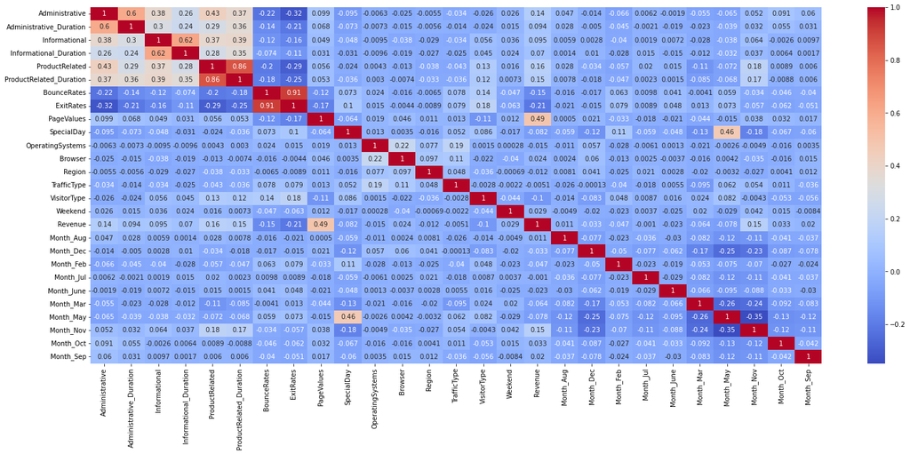

```python
plt.figure(figsize=(25,10))
sns.heatmap(df.corr(), annot=True, cmap='coolwarm')
plt.show()
```

```python
df.head(2)
```

|  | Administrative | Administrative_Duration | Informational | Informational_Duration | ProductRelated | ProductRelated_Duration | BounceRates | ExitRates | PageValues | SpecialDay | ... | Month_Aug | Month_Dec | Month_Feb | Month_Jul | Month_June | Month_Mar | Month_May | Month_Nov | Month_Oct | Month_Sep |
| --- | --- | --- | --- | --- | --- | --- | --- | --- | --- | --- | --- | --- | --- | --- | --- | --- | --- | --- | --- | --- | --- |
| 0 | 0 | 0.0 | 0 | 0.0 | 1 | 0.0 | 0.2 | 0.2 | 0.0 | 0.0 | ... | 0 | 0 | 1 | 0 | 0 | 0 | 0 | 0 | 0 | 0 |
| 1 | 0 | 0.0 | 0 | 0.0 | 2 | 64.0 | 0.0 | 0.1 | 0.0 | 0.0 | ... | 0 | 0 | 1 | 0 | 0 | 0 | 0 | 0 | 0 | 0 |

2 rows × 27 columns

```python
df = df.drop(['SpecialDay', 'OperatingSystems', 'Browser', 'Region', 'TrafficType', 'VisitorType', 'Weekend','Month_Aug', 'Month_Dec', 'Month_Feb', 'Month_Jul', 'Month_June', 'Month_Mar', 'Month_May', 'Month_Nov', 'Month_Oct', 'Month_Sep', 'PageValues'], axis=1)
```

```python
df.head(2)
```

|  | Administrative | Administrative_Duration | Informational | Informational_Duration | ProductRelated | ProductRelated_Duration | BounceRates | ExitRates | Revenue |
| --- | --- | --- | --- | --- | --- | --- | --- | --- | --- |
| 0 | 0 | 0.0 | 0 | 0.0 | 1 | 0.0 | 0.2 | 0.2 | 0 |
| 1 | 0 | 0.0 | 0 | 0.0 | 2 | 64.0 | 0.0 | 0.1 | 0 |

```python
df.isnull().sum()
```

```
Administrative             0
Administrative_Duration    0
Informational              0
Informational_Duration     0
ProductRelated             0
ProductRelated_Duration    0
BounceRates                0
ExitRates                  0
Revenue                    0
dtype: int64
```

In this step, the presence of null values is checked. However, no null values have been found.

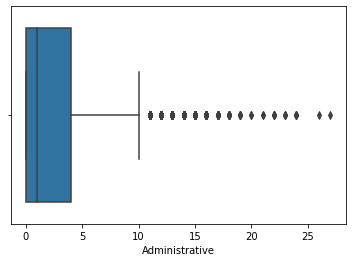

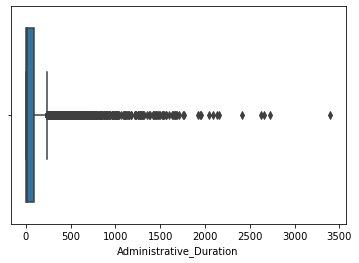

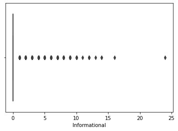

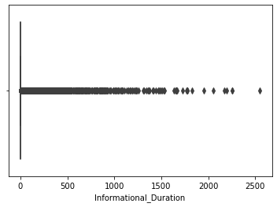

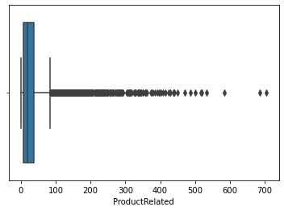

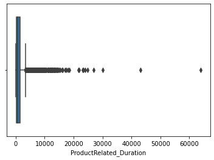

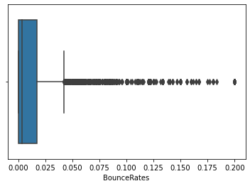

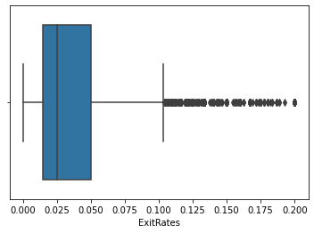

```python
outliers = ['Administrative', 'Administrative_Duration', 'Informational','Informational_Duration', 'ProductRelated', 'ProductRelated_Duration', 'BounceRates', 'ExitRates']
for col in outliers:
    plt.figure()
    sns.boxplot(x=col, data=df)
```

We discovered a significant number of outliers in our dataset, particularly in the features "Informational" and "Informational_Duration".